# PADP8120 Midterm Fall 2015

Thomas K. Valentine

October 14, 2015

# Data Source

We will analyze data from a New York City school voucher experiment (obtained by Dr. Tyler Scott and a colleague) from Mathematica.

```r
nyc = read.csv('input/NYC_SchoolVoucher_Experiment.csv',row.names=1)
```

# Variable Key

| Variable | Description |
| --- | --- |
| `Student_ID` | numerical code for each student |
| `Family_ID` | numerical code for each family |
| `Date.Of.Birth` | student birthday |
| `Female` | binary indicator for female students |
| `Grade` | student grade level when starting experiment |
| `Treatment` | binary indicator for whether student received voucher |
| `Latino` | binary indicator for Latino students |
| `Black` | binary indicator for black students |
| `Eldest` | binary indicator for eldest children |
| `y0_read_percentile` | pre-test reading score percentile |
| `y0_math_percentile` | pre-test math score percentile |
| `y1_read_percentile` | reading score percentile after 1y |
| `y1_math_percentile` | math score percentile after 1y |
| `y2_read_percentile` | reading score percentile after 2y |
| `y2_math_percentile` | math score percentile after 2y |
| `y3_read_percentile` | reading score percentile after 3y |
| `y3_math_percentile` | math score percentile after 3y |

# Problems

### 1. (6 points) Compute the average reading and math percentiles for each year across all students.

Using In-Line R Code, we can demonstrate the following values from our “nyc” data set:

#### Year 0

1. Average Reading % (across all students) is *22.78*
2. Average Math % (across all students) is *16.54*

#### Year 1

1. Average Reading % (across all students) is *26.06*
2. Average Math % (across all students): is *22.30*

#### Year 2

1. Average Reading % (across all students) is *26.09*
2. Average Math % (across all students) is *23.56*

#### Year 3

1. Average Reading % (across all students) is *32.63*
2. Average Math % (across all students) is *32.50*

#### Analysis:

*Reading: Increased significantly from year 0-1, then remained mostly unchanged from year 1-2, then increased again from year 2 to 3

*Math: Followed a very similar trend to math. Large increase from 0-1, stable from 1-2, increase from 2-3.

### 2. (4 points) Clean the original dataset by removing all students who do not have observe pre-test scores and year 1 scores for reading and for math.

```r
#We will create a new "clean" data set. To do so, we will create a subset of the original data set "nyc", where any observations contain blank ("NA") reading or math scores in Year Zero or Year 1.
nyc_clean <- subset(nyc, y0_read_percentile != "NA" & y0_math_percentile != "NA" & y1_read_percentile != "NA" & y0_read_percentile != "NA")

#Let's compare the dimensions of our original to our new data set
dim(nyc)
```

```
## [1] 2666   17
```

```r
dim(nyc_clean)
```

```
## [1] 1455   17
```

### 3. (8 points) Make a figure (either a density plot or a histogram format) comparing the distributions of percentile reading scores for students who did and did not receive a voucher. Do your best to make the figure “publishable” by giving it clear axis titles, legend labels, and other aesthetic improvements.

```r
library(dplyr)
```

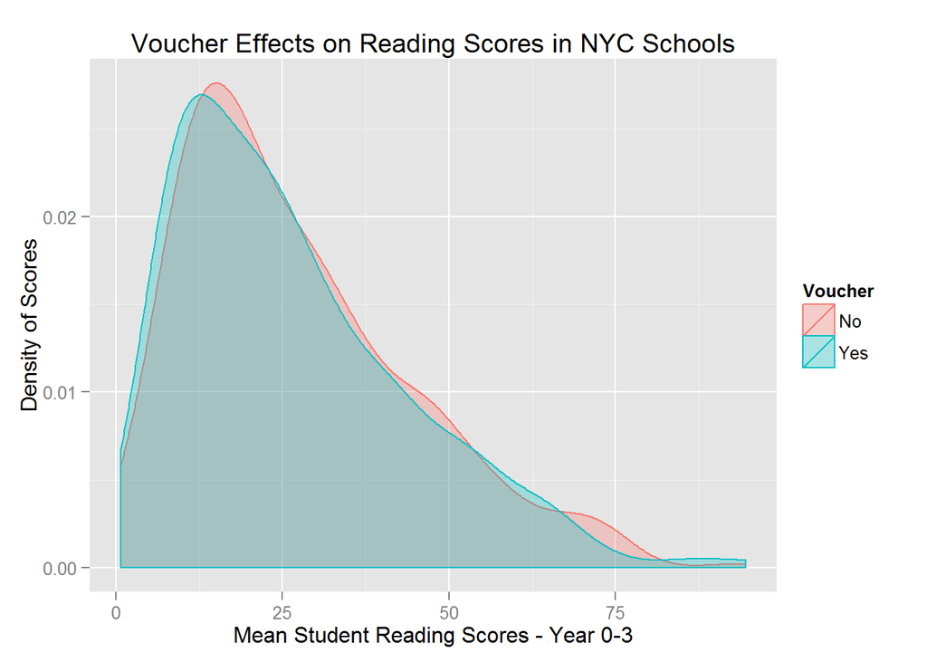

```r
library(ggplot2)

#First, we create a new variable, readingscores, that is the mean reading score for each student
nyc_clean$Reading <- (nyc_clean$y0_read_percentile + nyc_clean$y1_read_percentile + nyc_clean$y2_read_percentile + nyc_clean$y3_read_percentile)/4

#Second, we create a data set that contains only reading scores and treatment value
nycreading <- select(nyc_clean, Treatment, Reading)

#Next, we reorder the columns so we have our continuous variable (reading scores) first, then our binary treatment effect (0,1) second.
nycreading <- nycreading[c("Reading", "Treatment")]

#We omit observations with missing values, which drops 462 observations
nycreading <- na.omit(nycreading)

library(plyr)
#We rename the columns to suit our goals for the figure
nycreading <- rename(nycreading, c("Treatment"="Voucher", "Reading"="ReadingScores"))

#We convert our binary 0 and 1 values to 'Yes' and 'No' so that we can view the treatment groups as factors
nycreading[nycreading==0] <- 'No'
nycreading[nycreading==1] <- 'Yes'

#One item under Reading Scores is incorrectly coded in this process. We fix it here:
nycreading$ReadingScores[nycreading$ReadingScores=='Yes'] <- 1.00

#We recode Voucher as a Factor
nycreading$Voucher <- as.factor(nycreading$Voucher)
nycreading$ReadingScores <- as.numeric(nycreading$ReadingScores)

#Now, we can create our density plot:
p <- ggplot(nycreading, aes(x=ReadingScores)) + geom_density(aes(group=Voucher, colour=Voucher, fill=Voucher), alpha=0.3)

p + labs(title = "Voucher Effects on Reading Scores in NYC Schools") + xlab("Mean Student Reading Scores - Year 0-3") + ylab("Density of Scores")
```